# RandomForest

Diego Polo

4 de enero de 2018

# TITANIC SURVIVAL FORECASTING USING RANDOMFOREST ALGORITHM

This is my first kernel and I decided to use RamdonForest algorithm as many of features of datasets are factors and I think RandomForest clasificator would work fine

### Overview

The data has been split into two groups:

- training set (train.csv)
- test set (test.csv)

The training set should be used to build your machine learning models. For the training set, we provide the outcome (also known as the “ground truth”) for each passenger. Your model will be based on “features” like passengers’ gender and class. You can also use feature engineering to create new features.

The test set should be used to see how well your model performs on unseen data. For the test set, we do not provide the ground truth for each passenger. It is your job to predict these outcomes. For each passenger in the test set, use the model you trained to predict whether or not they survived the sinking of the Titanic.

We also include gender_submission.csv, a set of predictions that assume all and only female passengers survive, as an example of what a submission file should look like.

### Data Dictionary

VariableDefinitionKey survival Survival 0 = No, 1 = Yes pclass Ticket class 1 = 1st, 2 = 2nd, 3 = 3rd sex Sex Age Age in years sibsp # of siblings / spouses aboard the Titanic parch # of parents / children aboard the Titanic ticket Ticket number fare Passenger fare cabin Cabin number embarked Port of Embarkation C = Cherbourg, Q = Queenstown, S = Southampton

Variable Notes

pclass: A proxy for socio-economic status (SES)

- 1st = Upper
- 2nd = Middle
- 3rd = Lower

age: Age is fractional if less than 1. If the age is estimated, is it in the form of xx.5

sibsp: The dataset defines family relations in this way…

- Sibling = brother, sister, stepbrother, stepsister
- Spouse = husband, wife (mistresses and fiancés were ignored)

parch: The dataset defines family relations in this way…

- Parent = mother, father
- Child = daughter, son, stepdaughter, stepson Some children travelled only with a nanny, therefore parch=0 for them.

### Algorithm

First off, load libraries to use:

- *dplyr to* data manipulation and commands as group_by and %>% operator
- *ggplot2* and ggthemes for plotting

Dataset loading and fusion to operate in both dataset

```r
train=read.csv('./Data/train.csv',stringsAsFactors = FALSE,header = TRUE)
test=read.csv('./Data/test.csv',stringsAsFactors = FALSE,header = TRUE)
full=bind_rows(train,test)
summary(full)
```

```
##   PassengerId      Survived          Pclass          Name
##  Min.   :   1   Min.   :0.0000   Min.   :1.000   Length:1309
##  1st Qu.: 328   1st Qu.:0.0000   1st Qu.:2.000   Class :character
##  Median : 655   Median :0.0000   Median :3.000   Mode  :character
##  Mean   : 655   Mean   :0.3838   Mean   :2.295
##  3rd Qu.: 982   3rd Qu.:1.0000   3rd Qu.:3.000
##  Max.   :1309   Max.   :1.0000   Max.   :3.000
##                 NA's   :418
##      Sex                 Age            SibSp            Parch
##  Length:1309        Min.   : 0.17   Min.   :0.0000   Min.   :0.000
##  Class :character   1st Qu.:21.00   1st Qu.:0.0000   1st Qu.:0.000
##  Mode  :character   Median :28.00   Median :0.0000   Median :0.000
##                     Mean   :29.88   Mean   :0.4989   Mean   :0.385
##                     3rd Qu.:39.00   3rd Qu.:1.0000   3rd Qu.:0.000
##                     Max.   :80.00   Max.   :8.0000   Max.   :9.000
##                     NA's   :263
##     Ticket               Fare            Cabin
##  Length:1309        Min.   :  0.000   Length:1309
##  Class :character   1st Qu.:  7.896   Class :character
##  Mode  :character   Median : 14.454   Mode  :character
##                     Mean   : 33.295
##                     3rd Qu.: 31.275
##                     Max.   :512.329
##                     NA's   :1
##    Embarked
##  Length:1309
##  Class :character
##  Mode  :character
##
##
##
##
```

### Embarkment

Let’s check Embarkment. It shouldn’t provide info, it’s independent where you embarked and the sunk of Titanic. But I’ll check if there are NA in the dataset. Firstly I summarise number of passenger grouped by city of embarkment and lastly number of survivals by city (only in train as I don’t know outcomes for test)

```r
embarked_total=full%>%group_by(Embarked)%>%summarise(num_embarked=n())
print(embarked_total)
```

```
## # A tibble: 4 × 2
##   Embarked num_embarked
##      <chr>        <int>
## 1                     2
## 2        C          270
## 3        Q          123
## 4        S          914
```

```r
embarked_survived=full[1:891,]%>%filter(Survived==1)%>%group_by(Embarked)%>%summarise(num_survived=n())
print(embarked_survived)
```

```
## # A tibble: 4 × 2
##   Embarked num_survived
##      <chr>        <int>
## 1                     2
## 2        C           93
## 3        Q           30
## 4        S          217
```

```r
full$Mod_Embarked=ifelse(is.na(full$Embarked),'S',full$Embarked)
full$Mod_Embarked=as.factor(full$Mod_Embarked)
```

Let’s make some math, I will calculate percentages of these data

```r
embarked_total=full%>%group_by(Mod_Embarked)%>%summarise(num_embarked=n())
embarked_survived=full[1:891,]%>%filter(Survived==1)%>%group_by(Mod_Embarked)%>%summarise(num_survived=n())

embarked_total$percentage=embarked_total$num_embarked/sum(embarked_total$num_embarked)*100
embarked_survived$percentage=embarked_survived$num_survived/sum(embarked_survived$num_survived)*100
print(data.frame(City=embarked_total$Mod_Embarked, Total=embarked_total$percentage,
                 Survived=embarked_survived$percentage))
```

```
##   City      Total   Survived
## 1       0.1527884  0.5847953
## 2    C 20.6264324 27.1929825
## 3    Q  9.3964859  8.7719298
## 4    S 69.8242934 63.4502924
```

Data are very similar, i don’t think this is a good feature, but people from Cherbourg has higher rates of survival.

### Fares

I continue with ‘Fare’. I suppose that higher wealhty, more chances to survive (more boats on decks or not, it can spoil sightseens). Let’s do analysis (if it implied Survived I must take full[1,891,])

```r
summary(full$Fare)
```

```
##    Min. 1st Qu.  Median    Mean 3rd Qu.    Max.    NA's
##   0.000   7.896  14.450  33.300  31.280 512.300       1
```

```r
outcomes=full[1:891,]%>%group_by(Fare,Survived)%>%summarise(num_passengers=n())
print(head(outcomes))
```

```
## Source: local data frame [6 x 3]
## Groups: Fare [5]
##
##     Fare Survived num_passengers
##    <dbl>    <int>          <int>
## 1 0.0000        0             14
## 2 0.0000        1              1
## 3 4.0125        0              1
## 4 5.0000        0              1
## 5 6.2375        0              1
## 6 6.4375        0              1
```

- luxury >300 pounds
- 200>high>300
- 100>medium>200
- 50>low>100
- 0>extralow>50

and barplot the result

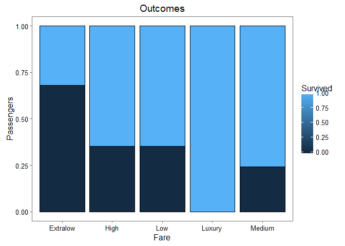

```r
full$Mod_FareLevels=ifelse(full$Fare>=0 & full$Fare<50,'Extralow',ifelse(full$Fare>=50 & full$Fare<100,'Low',ifelse(full$Fare>=100 & full$Fare<200,'Medium',ifelse(full$Fare>=200 & full$Fare<300,'High','Luxury'))))
full$Mod_FareLevels=as.factor(full$Mod_FareLevels)

outcome=full[1:891,] %>% group_by(Mod_FareLevels,Survived) %>% summarise(num_passenger=n())
ggplot(outcome,aes(x=Mod_FareLevels, y=num_passenger,fill = Survived))+
        geom_bar(stat='identity',position='fill', colour='black')+
        labs(y='Passengers', x='Fare',title='Outcomes')+
        ggthemes::theme_few()
```

As I supposed, most expensive fare passengers survived, maybe they were hosted in upper decks and had more time to get a boat. There’s 1 NA value to predict, let’s put the most likely value

```r
print(full%>%group_by(Mod_FareLevels)%>%summarise(n()))
```

```
## # A tibble: 6 × 2
##   Mod_FareLevels `n()`
##           <fctr> <int>
## 1       Extralow  1066
## 2           High    34
## 3            Low   158
## 4         Luxury     4
## 5         Medium    46
## 6             NA     1
```

```r
full$Mod_FareLevels[which(is.na(full$Mod_FareLevels))]='Extralow'
```

### Tickets

This feature is a mess!! I’ll take numbers and whether tickets are compound. At a glance compound tickets looks more poshy and expensive.

```r
full$Mod_CompoundTicket=as.factor(ifelse(grepl(pattern=" ",x=full$Ticket ),"Yes","No"))
full$Mod_NumberofTicket=sapply(full$Ticket, function(x) strsplit(x, split=" ")[[1]][2])
full$Mod_NumberofTicket=ifelse(is.na(full$Mod_NumberofTicket),full$Ticket,full$Mod_NumberofTicket)
```

I’ll check if compound tickets have something special

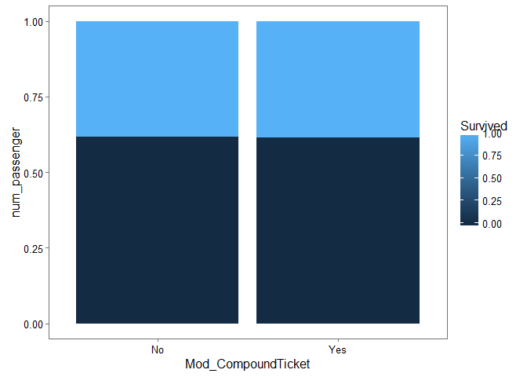

```r
outcome=full[1:891,]%>%group_by(Mod_CompoundTicket,Survived)%>%summarise(num_passenger=n())
ggplot(outcome, aes(x=Mod_CompoundTicket,y=num_passenger,fill=Survived))+
    geom_bar(stat="identity",position="fill")+ggthemes::theme_few()
```

It doesn’t give us any conclusions… There are some samples without numbers just letters, therefore I’ll force them to a 0

```r
full$Mod_NumberofTicket=ifelse(grepl(x=full$Mod_NumberofTicket,pattern="[0-9]"),full$Mod_NumberofTicket,"0")
full$NumeroDeTicket=as.numeric(full$Mod_NumberofTicket)
```

### Gender

Let’s check gender. “Women and children first” must have a meaning in this context.

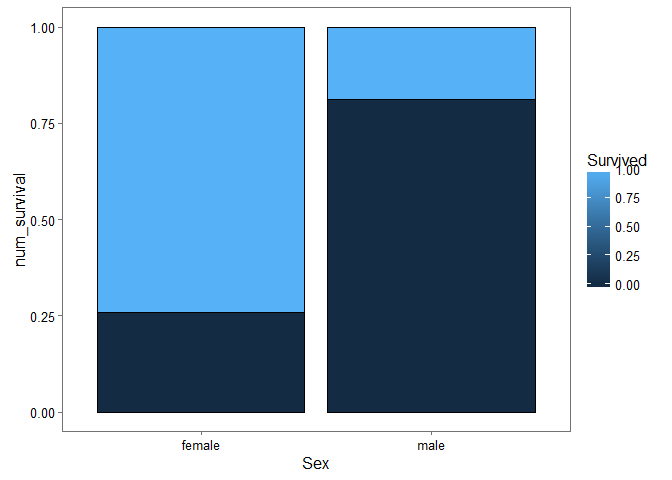

```r
full$Sex=as.factor(full$Sex)
outcome=full[1:891,]%>%group_by(Sex,Survived)%>%summarise(num_survival=n())
ggplot(outcome, aes(x=Sex,y=num_survival,fill=Survived))+
    geom_bar(stat='identity',position='fill', colour='Black')+ggthemes::theme_few()
```

Women have more rate of survivals, as expected

### Class

Let’s check if class give us any info, expected: higher class more survivals

```r
full$Pclass=as.factor(full$Pclass)
outcome=full[1:891,]%>%group_by(Pclass,Survived)%>%summarise(num_survival=n())
ggplot(outcome, aes(x=Pclass, y=num_survival,fill=Survived))+
    geom_bar(stat='identity', position='fill', colour='black')+ggthemes::theme_tufte()
```

[output not shown]

### Age

Mean age of survivals

```r
print(full[1:891,]%>%group_by(Survived)%>%summarise(mean_age=mean(Age,na.rm=TRUE)))
```

```
## # A tibble: 2 × 2
##   Survived mean_age
##      <int>    <dbl>
## 1        0 30.62618
## 2        1 28.34369
```

Histogram of age distribution

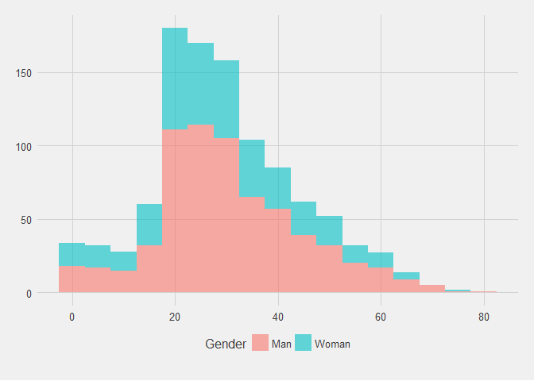

```r
agemen=full%>%filter(Sex=='male' & !is.na(Age))
agewomen=full%>%filter(Sex=='female' & !is.na(Age))
datamen=data.frame(Age=agemen$Age,Gender='Man')
datawomen=data.frame(Age=agewomen$Age,Gender='Woman')
data=rbind(datamen,datawomen)
ggplot(data, aes(Age,fill=Gender))+geom_histogram(alpha=0.6,binwidth = 5)+ggthemes::theme_fivethirtyeight()
```

No differences detected. Let’s classify age in a range: Kid, Teenager, Adult, Elder

```r
full$Mod_RangeAge=ifelse(full$Age<1,'Baby',
              ifelse(full$Age<5,'Kid',
              ifelse(full$Age<18, "Teenager",
              ifelse(full$Age<45,"Adult",
              ifelse(full$Age<90,"Elder",
              is.na())))))
```

Another plot to represent survival per age range

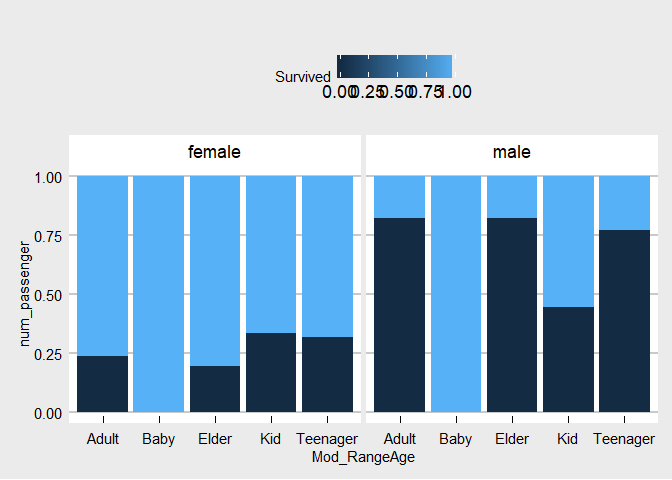

```r
outcome=full[1:891,]%>%group_by(Mod_RangeAge,Sex,Survived)%>%summarise(num_passenger=n())
ggplot(outcome, aes(x=Mod_RangeAge, y=num_passenger,fill=Survived))+
        geom_bar(stat='identity',position='fill')+
        facet_wrap(~Sex)+ggthemes::theme_economist_white()
```

conclusion: if you are male and you are not a child you die. If you are a woman you have more chance to survive. Being Age so important, it is paramount to predict ages witn NA values. There are 263 NA values. I’ll get more features and I will come back later to solve this issue

### Name

I reduce name to only surname as number of names is huge and full of treatment

```r
full$Mod_Surname=sapply(full$Name, function(x) strsplit(x,split=",")[[1]][1])
print(head(unique(as.factor(full$Mod_Surname))))
```

```
## [1] Braund    Cumings   Heikkinen Futrelle  Allen     Moran
## 875 Levels: Abbing Abbott Abelseth Abelson Abrahamsson Abrahim ... Zimmerman
```

I have reduced samples.

### SibSp and Parch

Other feature is wheather they are family or not, for that if SbSp o Parch are different from zero it implies there are relations. Family size could be another feature

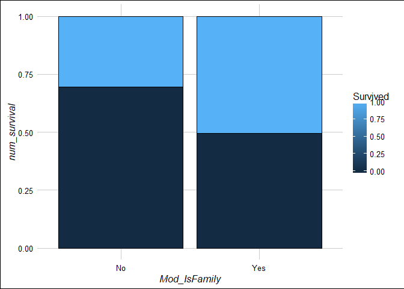

```r
full$Mod_IsFamily=as.factor(ifelse(full$SibSp>0 | full$Parch>0,"Yes","No"))
full$Mod_FamilySize=full$SibSp+full$Parch

outcome=full[1:891,]%>%group_by(Mod_IsFamily,Survived)%>%summarise(num_survival=n())
ggplot(outcome, aes(x=Mod_IsFamily, y=num_survival,fill=Survived))+
    geom_bar(stat='identity', position='fill', colour='black')+
    ggthemes::theme_gdocs()
```

Let’s examine if there is any correlation between survivals and sibSp and Parch

```r
outcome=full[1:891,]%>%group_by(SibSp,Survived)%>%summarise(num_survival=n())
outcome2=full[1:891,]%>%group_by(Parch,Survived)%>%summarise(num_survival=n())
full$Mod_SibSpParch=full$SibSp+full$Parch+1
outcome3=full[1:891,]%>%group_by(Mod_SibSpParch,Survived)%>%summarise(num_survival=n())
```

Plotting results to analyse

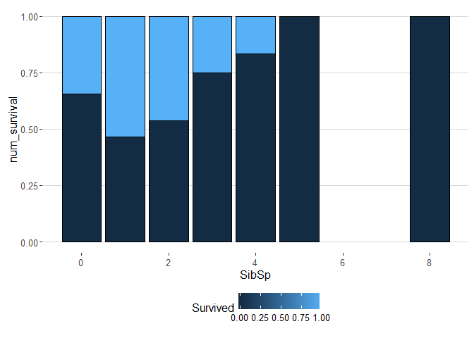

```r
ggplot(outcome, aes(x=SibSp, y=num_survival,fill=Survived))+
    geom_bar(stat='identity', position='fill', color='black')+
    ggthemes::theme_hc()
```

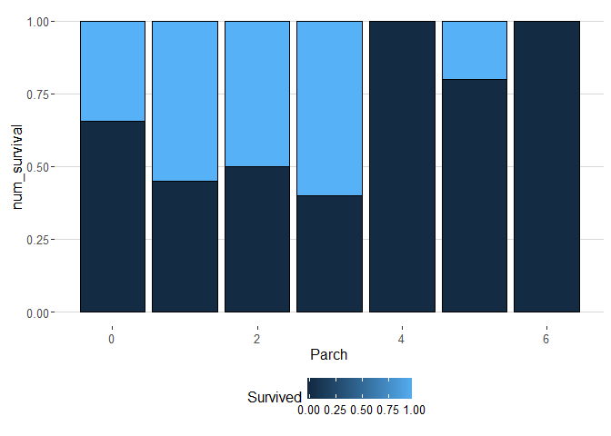

```r
ggplot(outcome2, aes(x=Parch, y=num_survival,fill=Survived))+
    geom_bar(stat='identity', position='fill', color='black')+
    ggthemes::theme_hc()
```

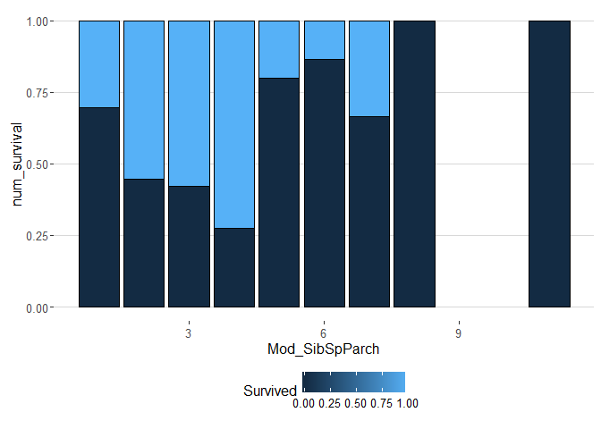

```r
ggplot(outcome3, aes(x=Mod_SibSpParch, y=num_survival,fill=Survived))+
    geom_bar(stat='identity', position='fill', color='black')+
    ggthemes::theme_hc()
```

Relation between FamilySize and Survival

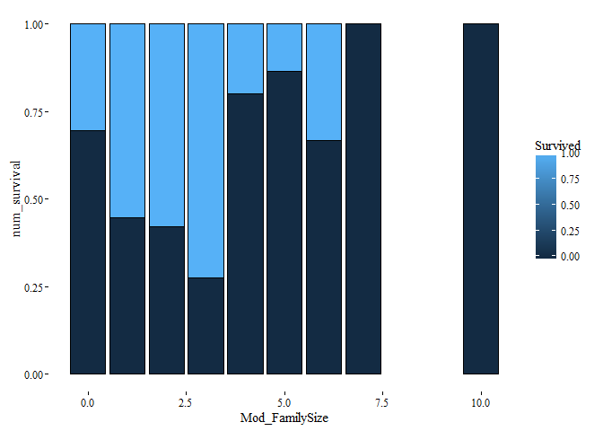

```r
outcome=full[1:891,]%>%group_by(Mod_FamilySize,Survived)%>%summarise(num_survival=n())
ggplot(outcome, aes(x=Mod_FamilySize,y=num_survival,fill=Survived))+
    geom_bar(stat='identity', position='fill', colour='black')+
    ggthemes::theme_tufte()
```

### Treatmen

```r
#extraction of treatments
data=sapply(full$Name, function(x) strsplit(x, split=", ")[[1]][2])
full$Mod_Treatment=sapply(data, function(x) strsplit(x, split="[.]")[[1]][1])
#number of treatments
print(levels(factor(full$Mod_Treatment)))
```

```
##  [1] "Capt"         "Col"          "Don"          "Dona"
##  [5] "Dr"           "Jonkheer"     "Lady"         "Major"
##  [9] "Master"       "Miss"         "Mlle"         "Mme"
## [13] "Mr"           "Mrs"          "Ms"           "Rev"
## [17] "Sir"          "the Countess"
```

```r
nombresmasculinos=c("Don","Dr","Jonkheer","Master","Mr","Rev","Sir")
nombresfemeninos=c("Dona","Mlle","Mme","Mrs","Ms","the Countess")
nombresmilitares=c("Capt","Col","Dr","Major")

full$Mod_Treatment=ifelse(grepl(paste(nombresmasculinos,collapse="|"),full$Mod_Treatment),"Mr",
           ifelse(grepl(paste(nombresfemeninos,collapse="|"), full$Mod_Treatment),"Mrs",
               ifelse(grepl(paste(nombresmilitares,collapse="|"), full$Mod_Treatment),"Officer",
               "Miss")))
full$Mod_Treatment=as.factor(full$Mod_Treatment)
```

### Deck

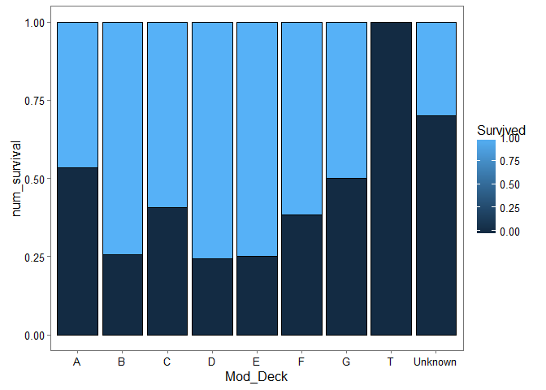

```r
full$Mod_Deck=sapply(full$Cabin, function(x) strsplit(x, split="")[[1]][1])
full$Mod_Deck[is.na(full$Mod_Deck)]="Unknown"
full$Mod_Deck=as.factor(full$Mod_Deck)

outcome=full[1:891,]%>%group_by(Mod_Deck,Survived)%>%summarise(num_survival=n())
ggplot(outcome, aes(x=Mod_Deck,y=num_survival,fill=Survived))+
    geom_bar(stat='identity',position='fill',colour='black')+
    ggthemes::theme_few()
```

Deck T is doomed :)

### Age 2

We will use rpart

```r
age_fit <- rpart(Age~ Pclass+Sex+Mod_FareLevels+Mod_CompoundTicket+Mod_IsFamily+Mod_Treatment+Mod_FamilySize+Mod_Deck,
              data = full[!is.na(full$Age), ],method = 'anova')

full$Mod_Age=full$Age

full$Mod_Age[is.na(full$Mod_Age)]=predict(age_fit, full[is.na(full$Mod_Age), ])

# All gone? Yes.
sum(is.na(full$Mod_Age))
```

```
## [1] 0
```

I re-apply RangeAge

```r
full$Mod_RangeAge=ifelse(full$Mod_Age<1,'Baby',
              ifelse(full$Mod_Age<5,'Kid',
              ifelse(full$Mod_Age<18, "Teenager",
              ifelse(full$Mod_Age<45,"Adult",
              ifelse(full$Mod_Age<90,"Elder",
              '')))))
full$Mod_RangeAge=as.factor(full$Mod_RangeAge)
```

### RandomForest

First check that all features are factors Let’s split data set in train and test subsets

```r
full$Survived=as.factor(full$Survived)
full$SibSp=as.factor(full$SibSp)
full$Parch=as.factor(full$Parch)

train=full[1:891,]
test=full[892:nrow(full),]
```

Set random seed

```r
set.seed(112)
```

Building the model and compute execution time

```r
start_time <- Sys.time()

rf_mod <- randomForest(Survived ~ Pclass+Sex+Mod_FareLevels+Mod_CompoundTicket+Mod_Age+Mod_IsFamily+Mod_Treatment+Mod_FamilySize+Mod_Deck,
  data = train,
  ntree = 2000,
  importance = TRUE)
end_time <- Sys.time()
print(paste0("Training excution time:",end_time - start_time))
```

```
## [1] "Training excution time:3.84225487709045"
```

Plotting errors

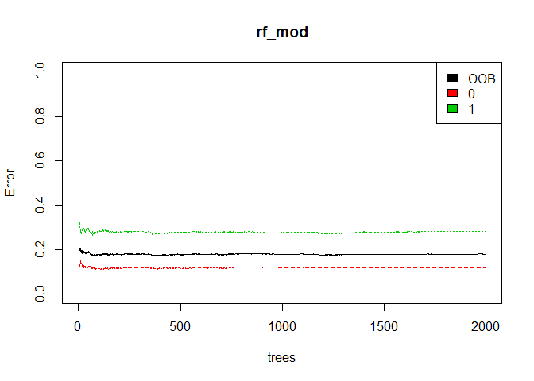

```r
plot(rf_mod, ylim=c(0,1))
legend('topright', colnames(rf_mod$err.rate), col=1:6, fill=1:6)
```

Get importance of features

```r
importance=importance(rf_mod)
print(head(importance))
```

```
##                             0        1 MeanDecreaseAccuracy
## Pclass              54.292797 42.00626             72.30158
## Sex                138.721872 85.94545            171.32128
## Mod_FareLevels      53.578603 18.44844             60.26958
## Mod_CompoundTicket   5.094897 14.55924             13.74239
## Mod_Age             39.010666 47.84770             65.26035
## Mod_IsFamily        12.311630 10.08528             18.12213
##                    MeanDecreaseGini
## Pclass                    30.503316
## Sex                       91.125155
## Mod_FareLevels            14.261591
## Mod_CompoundTicket         6.425522
## Mod_Age                   60.272300
## Mod_IsFamily               4.798528
```

```r
varImportance=data.frame(Variables = row.names(importance),
                            Importance = round(importance[ ,'MeanDecreaseGini'],2))
print(head(varImportance))
```

```
##                             Variables Importance
## Pclass                         Pclass      30.50
## Sex                               Sex      91.13
## Mod_FareLevels         Mod_FareLevels      14.26
## Mod_CompoundTicket Mod_CompoundTicket       6.43
## Mod_Age                       Mod_Age      60.27
## Mod_IsFamily             Mod_IsFamily       4.80
```

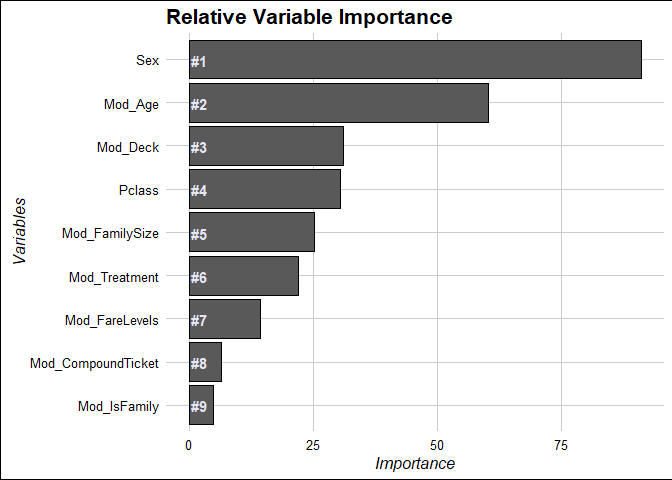

```r
# Create a rank variable based on importance
rankImportance=varImportance %>%mutate(Rank = paste0('#',dense_rank(desc(Importance))))

ggplot(rankImportance, aes(x = reorder(Variables, Importance),y = Importance)) +
  geom_bar(stat='identity', colour = 'black') +
  geom_text(aes(x = Variables, y = 0.5, label = Rank), hjust=0, vjust=0.55, size = 4, colour = 'lavender',    fontface = 'bold') +
  labs(x = 'Variables', title = 'Relative Variable Importance') +
  coord_flip() +
  theme_gdocs()
```

### Predictions

Predict using the test set

```r
prediction <- predict(rf_mod, test, type = 'response')
# Save the solution to a dataframe
solution = data.frame('PassengerId' = test$PassengerId, 'Survived'=as.numeric(levels(prediction))[prediction])
#solution = data.frame(prediction)
write.csv(solution, 'rf_solution.csv', row.names = FALSE)
```